# Stat240 Project Final

Noah Kornfeld, Karen Nam, Ethan Connelly, Peter Wang

2024-05-01

**Introduction**

In the complex landscape of economic analysis, the relationship between Gross Domestic Product (GDP) and employment/unemployment rates is a topic that many economists and statisticians alike have studied for hundreds of thousands of hours. Understanding how changes in GDP, a key indicator of economic health, influence employment dynamics is crucial for policymakers, economists, and businesses alike.

Okun’s Law, coined by economist Arthur Okun in the 1960s, states that a rise in employment is associated with a rise in GDP. From this, a question arises regarding the manifestation of this law in the United States economy. Is there a linear relationship between GDP (both Nominal and Real) and Unemployment and Employment rates in the United States? Through the exploration of datasets on GDP and employment/unemployment rates, this project will show that there does exist a linear relationship between GDP and employment rates in the United States.

**Background**

The data utilized for this project is from two primary sources: employment data from the USA Bureau of Labor Statistics and GDP data from the US Government’s Bureau of Economic Analysis.

The employment data, collected via the Current Population Survey, encompasses key variables such as:  
- **Population size**: Represents the size of the population in the sample  
- **Labor force size**: Represents the size of the population participating in the labor force (omits individuals not working and not actively seeking work)  
- **Unemployment/employment rates**: Represents the percentage of the population that is “unemployed” and “employed”

The employment data has been collected since 1940 which will give us nearly 85 years of numbers to work with. On the other hand, GDP data, sourced from the Bureau of Economic Analysis, includes variables such as:  
- **Nominal GDP**: Represents the total value of goods and services produced within a country’s borders without adjusting for inflation  
- **Real GDP**: Represents the total value of goods and services produced within a country’s borders, adjusting for inflation/deflation

The GDP data has been collected since 1930 which matches up quite well with the employment data in regards to similar starting periods. One potential unusual factor that may affect the interpretation of results is the presence of external shocks or economic events, such as financial crises or pandemics. These events can significantly impact both GDP and employment dynamics in ways that may not conform to typical trends. Additionally, structural changes in the economy, technological advancements, or shifts in government policies can influence the relationship between GDP and employment/unemployment rates. It’s essential to consider these factors and potentially account for them in the analysis to ensure a comprehensive understanding of the observed relationships.

**Analysis**

*Cleaning/Manipulating/Joining Datasets*

```
## # A tibble: 71 × 15
##     year population labor_force population_percent employed_total
##    <dbl>      <dbl>       <dbl>              <dbl>          <dbl>
##  1  1941      99900       55910               56            50350
##  2  1942      98640       56410               57.2          53750
##  3  1943      94640       55540               58.7          54470
##  4  1944      93220       54630               58.6          53960
##  5  1945      94090       53860               57.2          52820
##  6  1946     103070       57520               55.8          55250
##  7  1947     106018       60168               56.8          57812
##  8  1947     101827       59350               58.3          57038
##  9  1948     103068       60621               58.8          58343
## 10  1949     103994       61286               58.9          57651
## # ℹ 61 more rows
## # ℹ 10 more variables: employed_percent <dbl>, unemployed <dbl>,
## #   unemployed_percent <dbl>, not_in_labor <dbl>, nominal_gdp <dbl>,
## #   real_gdp <dbl>, nominal_growth_rate <dbl>, real_growth_rate <dbl>,
## #   employment_change <dbl>, unemployment_change <dbl>
```

**Graphical Summaries**

*Exploratory Graphs*

1. Employment/Unemployment Rates over Time

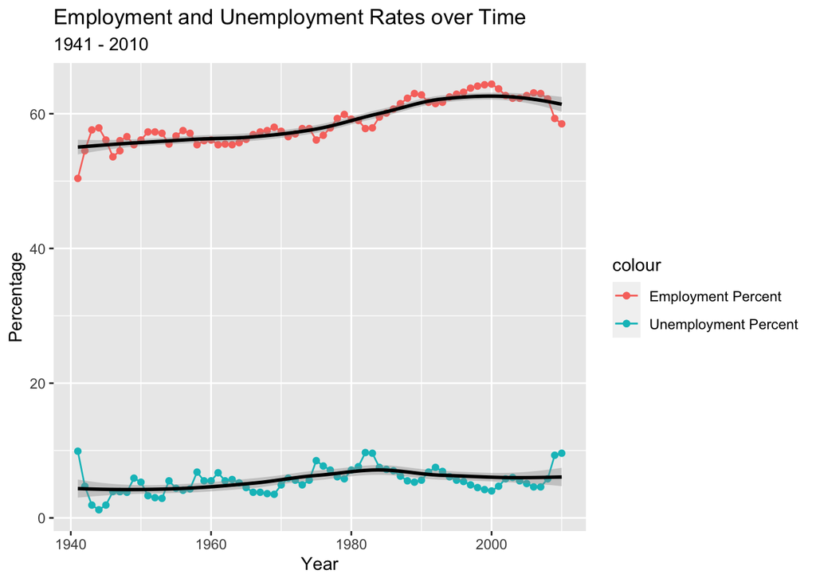

2. Employment/Unemployment/Labor Force Totals Over Time

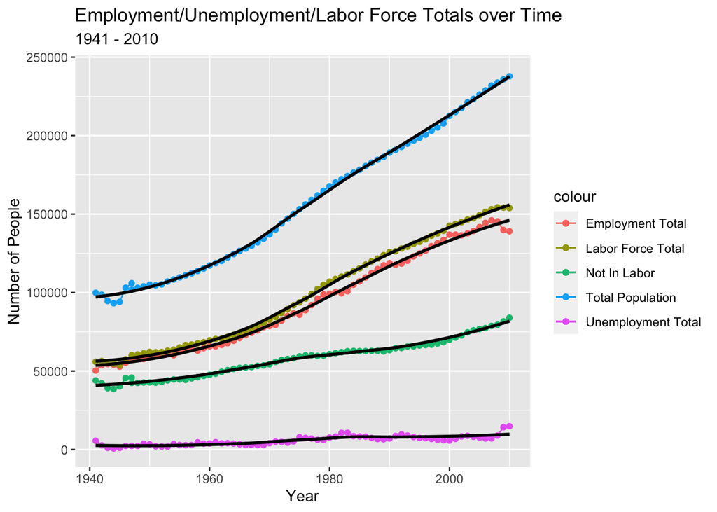

*Takeaways*  
This graph shows sharp increases in every counting column (population, labor force/non-labor force totals, and unemployment/employment totals). We can also see lots of symmetry on this graph. The difference between the Total Population and the Labor Force Total is accounted for by the “Not In Labor” measurement. The sliver betweeen the Employment and Labor Force totals can be seen as the Unemployment total. This makese both intuitive sense and reaffirms our understanding of the data.

3. Employment/Unemployment Percent Changes over Time

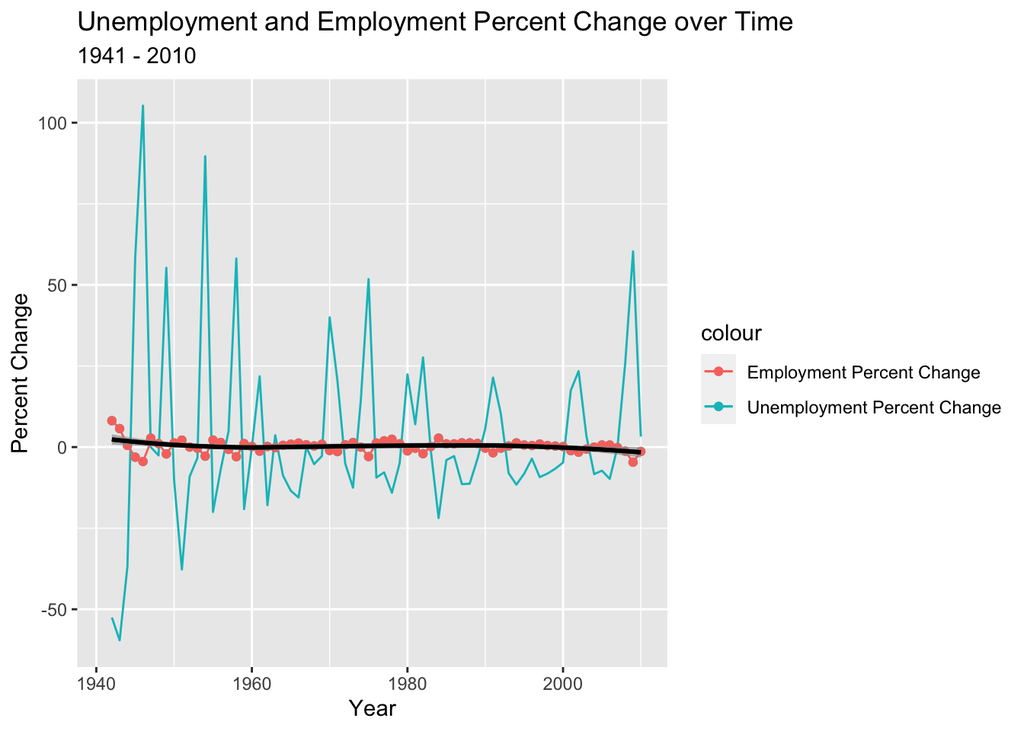

*Takeaways*  
This graph is extremely interesting. We see that while the change in employment percentage stays very stead over time, change in employment percentage is very volatile. This counteracts our previous notion of little to no change over time, however because unemployment rates are roughly between 1% and 10% (compared to employment rates between 50% and 60%) a smaller percent change will appear as more drastic for unemployment rates compare to employment rates. We will evaluate the effects of changes in GDP against changes in Employment/Unemployment rates in the comparison graphs section

4. Nominal vs Real GDP Over Time

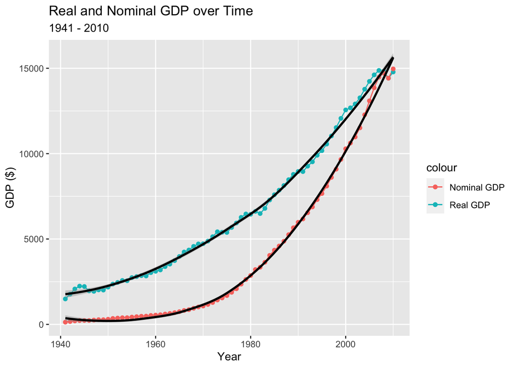

*Takeaways*  
Both Nominal and Real GDP follow a steady and consistent increase over time. This raises a question of cause. Because employment rates seem to stay somewhat level, we infer that this increase may be due to a population increase rather than changes in the employed population.

It is also worth noting the unique behavior near the top right of the graph. Nominal and Real GDP are essentially equal and even cross over which is behavior seen when inflation rates are extremely low or even negative. This makes sense given the recession in the United States and years following in the late 2000s and early 2010s in the United States

5. Nominal and Real GDP Growth Rates over Time

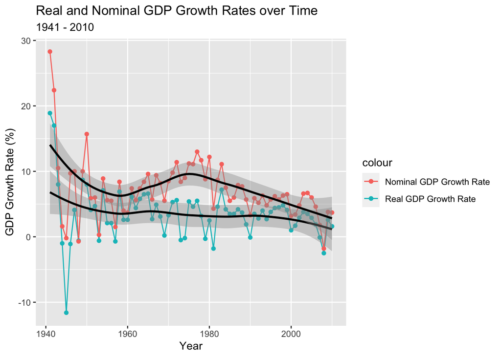

*Takeaways*  
In this graph we can see a very non-linear relationship between GDP growth rates and time. While the trendline shows a decrease, the actual data points are extremely volatile and do not seem to follow as linear of a trend.

The unique behavior in this graph can be similarly explained as the previous one. Real GDP growth rates and Nominal GDP growth rates are similar when inflation is negative and the sharp decline around the 1940s can be attributed to the exceptionally high inflation rates post-WWII.

Comparison Graph

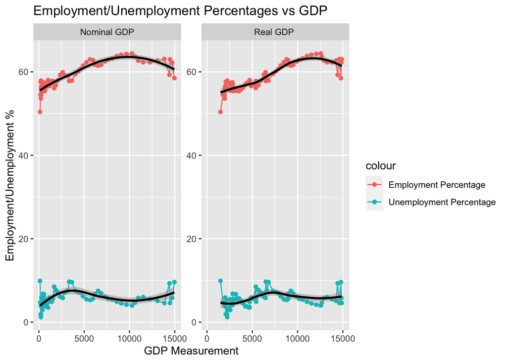

These 2 graphs indicate a somewhat linear relationship between GDP (both Nominal and Real) and Employment percentage. However, the fitted lines and points for Unemployment percentage do not seem to follow an increase or decrease as the GDP measurement increases. This relationship is what we are using to explore our question of interest and will dive into linear models in the Numerical Summaries Section

**Numerical Summaries**

In this section we will run 4 simple linear regression models to measure the effects of 2 response variables (Employment and Unemployment Percentage) against 2 covariates (Real and Nominal GDP)

1. Employment ~ Real GDP

```
##
## Call:
## lm(formula = employed_percent ~ real_gdp, data = combined_data)
##
## Residuals:
##     Min      1Q  Median      3Q     Max
## -5.5585 -0.9593  0.0489  1.1574  2.8209
##
## Coefficients:
##              Estimate Std. Error t value Pr(>|t|)
## (Intercept) 5.450e+01  3.646e-01  149.47   <2e-16 ***
## real_gdp    6.469e-04  4.675e-05   13.84   <2e-16 ***
## ---
## Signif. codes:  0 '***' 0.001 '**' 0.01 '*' 0.05 '.' 0.1 ' ' 1
##
## Residual standard error: 1.628 on 69 degrees of freedom
## Multiple R-squared:  0.7351, Adjusted R-squared:  0.7312
## F-statistic: 191.4 on 1 and 69 DF,  p-value: < 2.2e-16
```

The linear model suggests a significant linear relationship between Real GDP and Employment Percentage with a slope of 6.469e-04 and a corresponding p-value of <2e-16 which is significant at the 0.001 significance level. The model also has an R-squared statistic of 0.7351 indicating that 73.51% of the variance is explained by the linear model.

2. Employment ~ Nominal GDP

```
##
## Call:
## lm(formula = employed_percent ~ nominal_gdp, data = combined_data)
##
## Residuals:
##     Min      1Q  Median      3Q     Max
## -6.2141 -0.9690  0.2176  1.2955  3.3675
##
## Coefficients:
##              Estimate Std. Error t value Pr(>|t|)
## (Intercept) 5.654e+01  3.040e-01  186.02   <2e-16 ***
## nominal_gdp 5.460e-04  4.968e-05   10.99   <2e-16 ***
## ---
## Signif. codes:  0 '***' 0.001 '**' 0.01 '*' 0.05 '.' 0.1 ' ' 1
##
## Residual standard error: 1.907 on 69 degrees of freedom
## Multiple R-squared:  0.6364, Adjusted R-squared:  0.6312
## F-statistic: 120.8 on 1 and 69 DF,  p-value: < 2.2e-16
```

The linear model suggests a significant linear relationship between Nominal GDP and Employment Percentage with a slope of 5.460e-04 and a corresponding p-value of <2e-16 which is significant at the 0.001 significance level. The model also has an R-squared statistic of 0.6364 indicating that 63.64% of the variance is explained by the linear model.

3. Unemployment ~ Real GDP

```
##
## Call:
## lm(formula = unemployed_percent ~ real_gdp, data = combined_data)
##
## Residuals:
##     Min      1Q  Median      3Q     Max
## -3.7547 -1.1490 -0.2462  0.9841  5.0404
##
## Coefficients:
##              Estimate Std. Error t value Pr(>|t|)
## (Intercept) 4.670e+00  3.925e-01  11.898   <2e-16 ***
## real_gdp    1.269e-04  5.034e-05   2.522    0.014 *
## ---
## Signif. codes:  0 '***' 0.001 '**' 0.01 '*' 0.05 '.' 0.1 ' ' 1
##
## Residual standard error: 1.753 on 69 degrees of freedom
## Multiple R-squared:  0.08439,    Adjusted R-squared:  0.07113
## F-statistic:  6.36 on 1 and 69 DF,  p-value: 0.01398
```

4. Unemployment ~ Nominal GDP

```
##
## Call:
## lm(formula = unemployed_percent ~ nominal_gdp, data = combined_data)
##
## Residuals:
##     Min      1Q  Median      3Q     Max
## -3.9285 -1.2656 -0.2437  0.9252  4.7809
##
## Coefficients:
##              Estimate Std. Error t value Pr(>|t|)
## (Intercept) 5.106e+00  2.828e-01  18.059   <2e-16 ***
## nominal_gdp 9.881e-05  4.621e-05   2.138    0.036 *
## ---
## Signif. codes:  0 '***' 0.001 '**' 0.01 '*' 0.05 '.' 0.1 ' ' 1
##
## Residual standard error: 1.774 on 69 degrees of freedom
## Multiple R-squared:  0.06214,    Adjusted R-squared:  0.04855
## F-statistic: 4.572 on 1 and 69 DF,  p-value: 0.03604
```

Overall Discussion:  
The 4 numerical summaries when taken in the context of our question regarding the linear relationship between Unemployment/Employment and Real and Nominal GDP rates, we can see that the R-squared metrics, slopes, and corresponding p-values indicate a much stronger linear relationship between GDP measures and Employment rates and a weaker, but still present linear relationship between Unemployment rates and GDP measures.

**Discussion**

*Provide broader interpretations of your analysis and describe how to interpret your results with respect to your question of interest.*

*Discuss any potential short-comings of the analysis.*

- It may not be enough to analyze whether changes in GDP directly cause changes in employment or unemployment. In addition, both GDP and employment figures can be affected by other external factors, such as global economic conditions, technological changes, and government policies, which can complicate direct correlation analysis. Discuss potential future directions for additional work.

*Discuss potential future directions for additional work.*

*New questions*

- What are the industries that drive the relationship between GDP growth and employment/unemployment rate?

*Different methods to address the same questions*

- Another method to address the same question would be to run multiple linear regression models to see the effects of other economic indicators besides GDP on Employment and Unemployment rates.

*New data you might collect to refine your understanding*

- International data could be collected to compare the analysis whether the pattern observed is unique to the US or appears globally.

*Summarize your primary conclusions and the primary evidence that supports these conclusions.*

Primary conclusion:

- The primary conclusion is that there is a significant linear relationship between real GDP and employment rates, with real GDP explaining a substantial portion of the variation in employment rates. In contrast, the relationship between real GDP and unemployment rates is weaker and less significant, suggesting that other factors play a more dominant role in influencing unemployment rates.

**References**  
https://datahub.io/core/employment-us  
https://datahub.io/core/gdp-us  
https://datahub.io/core/inflation